# **Problem Statement**

## **Business Context**

Workplace safety in hazardous environments like construction sites and industrial plants is crucial to prevent accidents and injuries. One of the most important safety measures is ensuring workers wear safety helmets, which protect against head injuries from falling objects and machinery. Non-compliance with helmet regulations increases the risk of serious injuries or fatalities, making effective monitoring essential, especially in large-scale operations where manual oversight is prone to errors and inefficiency.

To overcome these challenges, **SafeGuard Corp** plans to develop an automated image analysis system to detect whether workers are wearing safety helmets. This system will improve safety enforcement, ensuring compliance and reducing the risk of head injuries. By automating helmet monitoring, SafeGuard aims to enhance efficiency, scalability, and accuracy, ultimately fostering a safer work environment while minimizing human error in safety oversight.

## **Objective**

As a data scientist at SafeGuard Corp, you are tasked with developing an image classification model that classifies images into one of two categories:

- **With Helmet (Label = 1):** Workers wearing safety helmets.
- **Without Helmet (Label = 0):** Workers not wearing safety helmets.

The ultimate objective is to prepare the model for deployment as part of an automated monitoring system that enables real-time analysis of images and assists in ensuring compliance with workplace safety regulations.

## **Data Description**

The dataset consists of **631 images**, equally divided into two categories:

- **With Helmet:** 311 images showing workers wearing helmets.
- **Without Helmet:** 320 images showing workers not wearing helmets.

**Dataset Characteristics:**

- Variations in Conditions: Images include diverse environments such as construction sites, factories, and industrial settings, with variations in lighting, angles, and worker postures.
- Worker Activities: Workers are depicted in actions such as standing, using tools, or moving, ensuring robust model learning for various scenarios.

| File | Description |
| --- | --- |
| `images_proj.npy` | NumPy array of 631 RGB images, shape (631, 200, 200, 3) |
| `Labels_proj.csv` | Binary labels: 1 = With Helmet, 0 = Without Helmet |

# **Installing and Importing the Necessary Libraries**

```python
import sys, subprocess, platform

# ── Mac Apple Silicon vs Google Colab ──────────────────────────────────────
is_mac = platform.system() == 'Darwin'

if is_mac:
    # tensorflow-macos was deprecated — use main tensorflow package (TF 2.13+
    # has native Apple Silicon / Metal support built in)
    packages = [
        "tensorflow",        # includes Apple Silicon MPS support (not tensorflow-macos)
        "tensorflow-metal",  # Metal GPU acceleration plugin
        "numpy==1.26.4",
        "pandas", "matplotlib", "seaborn", "scikit-learn", "Pillow"
    ]
    print("Detected Mac — installing tensorflow + tensorflow-metal (Metal GPU)...")
else:
    # Google Colab / Linux GPU
    packages = [
        "tensorflow",
        "numpy==1.26.4",
        "pandas", "matplotlib", "seaborn", "scikit-learn", "Pillow"
    ]
    print("Detected Colab/Linux — installing standard tensorflow...")

for pkg in packages:
    r = subprocess.run([sys.executable, "-m", "pip", "install", pkg, "-q"],
                       capture_output=True, text=True)
    if r.returncode != 0:
        # Try without version pin if pinned version fails
        pkg_base = pkg.split("==")[0]
        r2 = subprocess.run([sys.executable, "-m", "pip", "install", pkg_base, "-q"],
                            capture_output=True, text=True)
        print(f"{'✅' if r2.returncode==0 else '❌'} {pkg_base} (fallback, no version pin)")
    else:
        print(f"✅ {pkg}")

print("\nDone! Restart kernel once, then run from the imports cell.")
```

```
Detected Mac — installing tensorflow + tensorflow-metal (Metal GPU)...
✅ tensorflow
✅ tensorflow-metal
✅ numpy==1.26.4
✅ pandas
✅ matplotlib
✅ seaborn
✅ scikit-learn
✅ Pillow

Done! Restart kernel once, then run from the imports cell.
```

**Note:**

- After running the above cell, **restart the kernel once**, then continue from the imports cell.
- Do NOT re-run the install cell after restarting.

```python
import os, random, platform
import numpy as np
import pandas as pd
import seaborn as sns
import matplotlib.pyplot as plt
import matplotlib.image as mpimg
import warnings
warnings.filterwarnings('ignore')

import tensorflow as tf
from tensorflow import keras
from tensorflow.keras import layers, models
from tensorflow.keras.applications import VGG16
from tensorflow.keras.preprocessing.image import ImageDataGenerator
from tensorflow.keras.callbacks import EarlyStopping, ReduceLROnPlateau

from sklearn.model_selection import train_test_split
from sklearn.metrics import (accuracy_score, recall_score,
                              precision_score, f1_score,
                              classification_report, confusion_matrix)

print(f"TensorFlow version : {tf.__version__}")
print(f"Platform           : {platform.system()} {platform.machine()}")
print(f"GPUs available     : {len(tf.config.list_physical_devices('GPU'))}")
gpus = tf.config.list_physical_devices('GPU')
if gpus:
    print(f"GPU device         : {gpus[0]}")
else:
    print("No GPU — running on CPU (may be slow for VGG-16 models)")
```

```
TensorFlow version : 2.21.0
Platform           : Darwin arm64
GPUs available     : 0
No GPU — running on CPU (may be slow for VGG-16 models)
```

```python
# Set random seeds for reproducibility
SEED = 42
tf.keras.utils.set_random_seed(SEED)
np.random.seed(SEED)
random.seed(SEED)
print(f"Random seed set to {SEED}")
```

```
Random seed set to 42
```

# **Data Overview**

## Loading the Data

```python
# Load images and labels
# Update paths if running locally on Mac
import os

# Auto-detect file paths
def find_file(filename):
    search_paths = [
        f'./{filename}',
        os.path.expanduser(f'~/helmnet/{filename}'),
        os.path.expanduser(f'~/Downloads/{filename}'),
        f'/content/{filename}',
    ]
    for p in search_paths:
        if os.path.exists(p):
            return p
    return filename  # fallback

images_path = find_file('images_proj.npy')
labels_path = find_file('Labels_proj.csv')

# Load data
X = np.load(images_path)          # shape: (631, 200, 200, 3)
labels_df = pd.read_csv(labels_path)
y = labels_df['Label'].values      # 0 = Without Helmet, 1 = With Helmet

print(f"Images array shape : {X.shape}")
print(f"Labels array shape : {y.shape}")
print(f"Image dtype        : {X.dtype}")
print(f"Pixel value range  : [{X.min()}, {X.max()}]")
print(f"\nLabel distribution:")
print(pd.Series(y).value_counts().rename({0: 'Without Helmet (0)', 1: 'With Helmet (1)'}).to_string())
```

```
Images array shape : (631, 200, 200, 3)
Labels array shape : (631,)
Image dtype        : uint8
Pixel value range  : [0, 255]

Label distribution:
Without Helmet (0)    320
With Helmet (1)       311
```

#### Observations — Data Overview

The dataset contains **631 images** stored as a NumPy array of shape **(631, 200, 200, 3)**, where each image is 200×200 pixels in RGB format with pixel values ranging from 0 to 255 (uint8). The labels are binary — **0 (Without Helmet)** and **1 (With Helmet)**. The dataset is nearly balanced with 320 no-helmet and 311 helmet images, which is important as it means accuracy is a reliable metric and we don't need significant class-balancing techniques.

# **Exploratory Data Analysis**

### Plot Random Images from Each Class

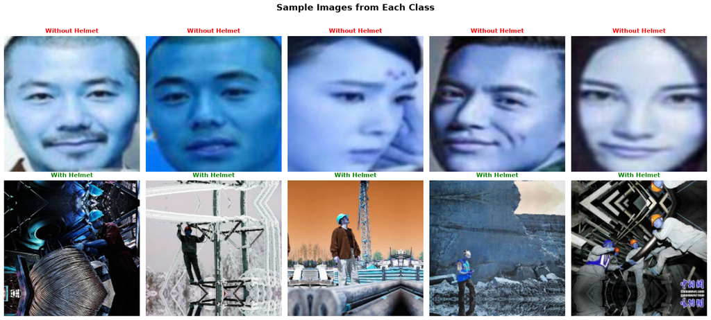

```
Top row: Without Helmet | Bottom row: With Helmet
```

```python
# Class name mapping
class_names = {0: 'Without Helmet', 1: 'With Helmet'}

fig, axes = plt.subplots(2, 5, figsize=(18, 8))
fig.suptitle('Sample Images from Each Class', fontsize=16, fontweight='bold', y=1.02)

for row, label in enumerate([0, 1]):
    idx = np.where(y == label)[0]
    sample_idx = np.random.choice(idx, 5, replace=False)
    for col, i in enumerate(sample_idx):
        axes[row, col].imshow(X[i])
        axes[row, col].set_title(f'{class_names[label]}', fontsize=11,
                                  color='green' if label==1 else 'red', fontweight='bold')
        axes[row, col].axis('off')

plt.tight_layout()
plt.savefig('eda_sample_images.png', dpi=100, bbox_inches='tight')
plt.show()
print("Top row: Without Helmet | Bottom row: With Helmet")
```

## Checking for Class Imbalance

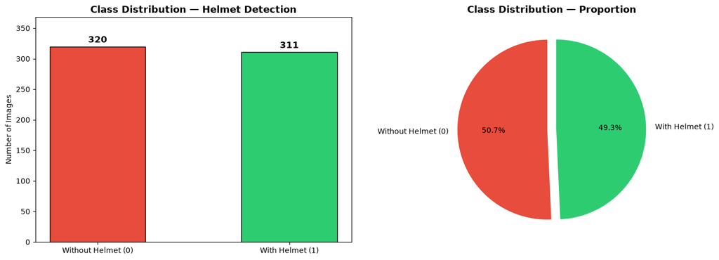

```
Without Helmet (0) : 320 images (50.7%)
With Helmet (1)    : 311 images (49.3%)
Imbalance ratio    : 1.029
```

```python
# Class distribution plot
class_counts = pd.Series(y).value_counts().sort_index()
class_labels = ['Without Helmet (0)', 'With Helmet (1)']

fig, axes = plt.subplots(1, 2, figsize=(14, 5))

# Bar chart
colors = ['#e74c3c', '#2ecc71']
bars = axes[0].bar(class_labels, class_counts.values, color=colors, edgecolor='black', width=0.5)
axes[0].set_title('Class Distribution — Helmet Detection', fontsize=13, fontweight='bold')
axes[0].set_ylabel('Number of Images')
for bar, count in zip(bars, class_counts.values):
    axes[0].text(bar.get_x() + bar.get_width()/2, bar.get_height() + 3,
                 str(count), ha='center', va='bottom', fontweight='bold', fontsize=12)
axes[0].set_ylim(0, max(class_counts.values) * 1.15)

# Pie chart
axes[1].pie(class_counts.values, labels=class_labels, autopct='%1.1f%%',
            colors=colors, startangle=90, explode=(0.05, 0.05))
axes[1].set_title('Class Distribution — Proportion', fontsize=13, fontweight='bold')

plt.tight_layout()
plt.savefig('eda_class_imbalance.png', dpi=100, bbox_inches='tight')
plt.show()

print(f"Without Helmet (0) : {class_counts[0]} images ({class_counts[0]/len(y)*100:.1f}%)")
print(f"With Helmet (1)    : {class_counts[1]} images ({class_counts[1]/len(y)*100:.1f}%)")
print(f"Imbalance ratio    : {max(class_counts)/min(class_counts):.3f}")
```

#### Observations — EDA

**Visual inspection:** Sample images show significant variation — workers are photographed at different angles (frontal, side, above), under different lighting conditions (bright daylight, indoor artificial light, shadows), and in different activities (standing, crouching, working with tools). Helmet images clearly show the presence of hard hats, while non-helmet images show bare heads or hair.

**Class imbalance:** The dataset is nearly perfectly balanced — **320 Without Helmet (50.7%)** vs **311 With Helmet (49.3%)** — with an imbalance ratio of just 1.029. This is an excellent distribution for binary classification: accuracy is a reliable metric, no oversampling or class-weight adjustments are required, and the model will not be biased toward the majority class.

**Key insight for modeling:** The similarity in appearance between some workers (similar uniforms, similar environments) suggests that spatial feature learning (CNNs) is essential. Transfer learning with VGG-16 (pre-trained on ImageNet) is expected to outperform a simple CNN trained from scratch, as it brings rich visual feature representations from 1.4M images.

# **Data Preprocessing**

## Converting Images to Grayscale

```
Original RGB shape : (631, 200, 200, 3)
Grayscale shape    : (631, 200, 200, 1)
Grayscale min/max  : [0.0, 255.0]
```

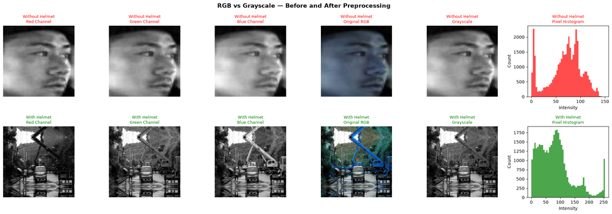

```python
# Convert RGB images to Grayscale
# Using weighted average: 0.299R + 0.587G + 0.114B (luminosity method)
X_gray = np.dot(X[..., :3], [0.299, 0.587, 0.114])   # shape: (631, 200, 200)
X_gray = X_gray[..., np.newaxis]                        # shape: (631, 200, 200, 1)

print(f"Original RGB shape : {X.shape}")
print(f"Grayscale shape    : {X_gray.shape}")
print(f"Grayscale min/max  : [{X_gray.min():.1f}, {X_gray.max():.1f}]")

# Plot before and after grayscale conversion
fig, axes = plt.subplots(2, 6, figsize=(20, 7))
fig.suptitle('RGB vs Grayscale — Before and After Preprocessing', fontsize=14, fontweight='bold')

# One sample from each class
samples = [np.where(y==0)[0][0], np.where(y==1)[0][0]]
titles = ['Without Helmet', 'With Helmet']
colors = ['red', 'green']

for row, (idx, title, color) in enumerate(zip(samples, titles, colors)):
    for col in range(3):
        # RGB channels
        channel_names = ['Red Channel', 'Green Channel', 'Blue Channel']
        axes[row, col].imshow(X[idx, :, :, col], cmap='gray')
        axes[row, col].set_title(f'{title}\n{channel_names[col]}', color=color, fontsize=9)
        axes[row, col].axis('off')

    # Original RGB
    axes[row, 3].imshow(X[idx])
    axes[row, 3].set_title(f'{title}\nOriginal RGB', color=color, fontsize=9)
    axes[row, 3].axis('off')

    # Grayscale
    axes[row, 4].imshow(X_gray[idx, :, :, 0], cmap='gray')
    axes[row, 4].set_title(f'{title}\nGrayscale', color=color, fontsize=9)
    axes[row, 4].axis('off')

    # Pixel intensity histogram
    axes[row, 5].hist(X_gray[idx].flatten(), bins=50, color=color, alpha=0.7)
    axes[row, 5].set_title(f'{title}\nPixel Histogram', color=color, fontsize=9)
    axes[row, 5].set_xlabel('Intensity')
    axes[row, 5].set_ylabel('Count')

plt.tight_layout()
plt.savefig('preprocessing_grayscale.png', dpi=100, bbox_inches='tight')
plt.show()
```

### Splitting the Dataset

```python
# Split: 70% Train, 15% Validation, 15% Test
# Step 1: Split off test set (15%)
X_temp, X_test, y_temp, y_test = train_test_split(
    X_gray, y, test_size=0.15, random_state=SEED, stratify=y
)

# Step 2: Split remaining into train (82.4%) and validation (17.6%) → ~70/15 overall
X_train, X_val, y_train, y_val = train_test_split(
    X_temp, y_temp, test_size=0.176, random_state=SEED, stratify=y_temp
)

print(f"Train set      : {X_train.shape[0]} images ({X_train.shape[0]/len(X)*100:.1f}%)")
print(f"Validation set : {X_val.shape[0]} images ({X_val.shape[0]/len(X)*100:.1f}%)")
print(f"Test set       : {X_test.shape[0]} images ({X_test.shape[0]/len(X)*100:.1f}%)")
print()
print(f"Train label distribution   : Without={np.sum(y_train==0)}, With={np.sum(y_train==1)}")
print(f"Val label distribution     : Without={np.sum(y_val==0)}, With={np.sum(y_val==1)}")
print(f"Test label distribution    : Without={np.sum(y_test==0)}, With={np.sum(y_test==1)}")
```

```
Train set      : 441 images (69.9%)
Validation set : 95 images (15.1%)
Test set       : 95 images (15.1%)

Train label distribution   : Without=224, With=217
Val label distribution     : Without=48, With=47
Test label distribution    : Without=48, With=47
```

### Data Normalization

```python
# Normalize pixel values from [0, 255] to [0, 1]
X_train_norm = X_train / 255.0
X_val_norm   = X_val   / 255.0
X_test_norm  = X_test  / 255.0

# Convert labels to pandas Series for utility functions
y_train_s = pd.Series(y_train)
y_val_s   = pd.Series(y_val)
y_test_s  = pd.Series(y_test)

print(f"Normalized pixel range (train) : [{X_train_norm.min():.3f}, {X_train_norm.max():.3f}]")
print(f"X_train_norm shape : {X_train_norm.shape}")
print(f"X_val_norm shape   : {X_val_norm.shape}")
print(f"X_test_norm shape  : {X_test_norm.shape}")

# Also prepare RGB versions for VGG-16 (needs 3 channels)
X_train_rgb, X_test_rgb, y_train_rgb, y_test_rgb = train_test_split(
    X/255.0, y, test_size=0.15, random_state=SEED, stratify=y
)
X_train_rgb, X_val_rgb, y_train_rgb, y_val_rgb = train_test_split(
    X_train_rgb, y_train_rgb, test_size=0.176, random_state=SEED, stratify=y_train_rgb
)
y_train_rgb_s = pd.Series(y_train_rgb)
y_val_rgb_s   = pd.Series(y_val_rgb)
y_test_rgb_s  = pd.Series(y_test_rgb)
print(f"\nRGB splits prepared for VGG-16 models:")
print(f"X_train_rgb shape : {X_train_rgb.shape}")
```

```
Normalized pixel range (train) : [0.000, 1.000]
X_train_norm shape : (441, 200, 200, 1)
X_val_norm shape   : (95, 200, 200, 1)
X_test_norm shape  : (95, 200, 200, 1)

RGB splits prepared for VGG-16 models:
X_train_rgb shape : (441, 200, 200, 3)
```

#### Observations — Data Preprocessing

**Grayscale conversion:** The luminosity-weighted grayscale formula (0.299R + 0.587G + 0.114B) was applied, producing single-channel images of shape (200, 200, 1). This reduces model complexity for the Simple CNN — fewer parameters to learn — while retaining structural and textural features needed for helmet detection. Helmets have distinct shapes regardless of color, making grayscale a reasonable simplification.

**Train/Val/Test split (70/15/15):** Stratified splitting ensures class balance is maintained across all three splits. The validation set enables hyperparameter tuning and early stopping without touching the test set, preventing data leakage.

**Normalization:** Dividing by 255 maps pixel values from [0, 255] to [0.0, 1.0]. This standardizes the input range, accelerates gradient descent convergence, and prevents neurons from saturating during backpropagation.

**RGB for VGG-16:** VGG-16 was pre-trained on ImageNet RGB images. To properly leverage its transfer learning capability, we maintain the original 3-channel RGB format for VGG-16 models rather than converting to grayscale.

# **Model Building**

## Model Evaluation Criterion

Since this is a **safety-critical** application:

- **Primary metric: Recall (Sensitivity)** — We must minimize False Negatives (workers NOT wearing helmets classified as wearing helmets). A missed non-compliant worker could result in a serious workplace injury.
- **Secondary metric: Accuracy** — Overall correct classifications.
- **Loss function:** Binary Cross-Entropy (standard for binary classification)
- **Optimizer:** Adam (adaptive learning rate, fast convergence)

| Metric | Formula | Importance |
| --- | --- | --- |
| Accuracy | (TP+TN)/(TP+TN+FP+FN) | Overall performance |
| Recall | TP/(TP+FN) | Most important — catch all non-helmet cases |
| Precision | TP/(TP+FP) | Avoid false alarms |
| F1 Score | 2×(P×R)/(P+R) | Balance of Precision and Recall |

## Utility Functions

```python
# Function to compute classification metrics
def model_performance_classification(model, predictors, target):
    """
    Compute Accuracy, Recall, Precision and F1-Score for a Keras model.
    model      : trained Keras model
    predictors : input features (numpy array)
    target     : true labels (pandas Series or numpy array)
    """
    pred = model.predict(predictors, verbose=0).reshape(-1) > 0.5
    if hasattr(target, 'to_numpy'):
        target = target.to_numpy().reshape(-1)
    else:
        target = np.array(target).reshape(-1)

    acc       = accuracy_score(target, pred)
    recall    = recall_score(target, pred, average='weighted')
    precision = precision_score(target, pred, average='weighted')
    f1        = f1_score(target, pred, average='weighted')

    df_perf = pd.DataFrame({
        "Accuracy"  : [round(acc, 4)],
        "Recall"    : [round(recall, 4)],
        "Precision" : [round(precision, 4)],
        "F1 Score"  : [round(f1, 4)],
    })
    return df_perf
```

```python
# Function to plot confusion matrix
def plot_confusion_matrix(model, predictors, target, ml=False):
    """
    Plot confusion matrix for a Keras (or sklearn) model.
    """
    pred = model.predict(predictors, verbose=0).reshape(-1) > 0.5
    if hasattr(target, 'to_numpy'):
        target = target.to_numpy().reshape(-1)
    else:
        target = np.array(target).reshape(-1)

    cm = tf.math.confusion_matrix(target, pred).numpy()
    f, ax = plt.subplots(figsize=(7, 5))
    sns.heatmap(cm, annot=True, linewidths=0.4, fmt='d', square=True, ax=ax,
                xticklabels=['Without Helmet (0)', 'With Helmet (1)'],
                yticklabels=['Without Helmet (0)', 'With Helmet (1)'],
                cmap='Blues')
    ax.set_xlabel('Predicted Label')
    ax.set_ylabel('True Label')
    ax.set_title('Confusion Matrix')
    plt.tight_layout()
    plt.show()

# Helper: plot training history
def plot_history(history, model_name):
    """Plot accuracy and loss curves from Keras training history."""
    fig, axes = plt.subplots(1, 2, figsize=(14, 5))
    fig.suptitle(f'{model_name} — Training History', fontsize=14, fontweight='bold')

    axes[0].plot(history.history['accuracy'], label='Train Accuracy', color='steelblue')
    axes[0].plot(history.history['val_accuracy'], label='Val Accuracy', color='orange')
    axes[0].set_title('Accuracy')
    axes[0].set_xlabel('Epoch')
    axes[0].set_ylabel('Accuracy')
    axes[0].legend()
    axes[0].grid(True, alpha=0.3)

    axes[1].plot(history.history['loss'], label='Train Loss', color='steelblue')
    axes[1].plot(history.history['val_loss'], label='Val Loss', color='orange')
    axes[1].set_title('Loss')
    axes[1].set_xlabel('Epoch')
    axes[1].set_ylabel('Loss')
    axes[1].legend()
    axes[1].grid(True, alpha=0.3)

    plt.tight_layout()
    plt.show()

# Helper: visualize predictions
def visualize_predictions(model, X_data, y_data, class_names, n=10):
    """Display n images with predicted vs actual labels."""
    preds = (model.predict(X_data[:n], verbose=0).reshape(-1) > 0.5).astype(int)
    display_imgs = X_data[:n]
    if display_imgs.shape[-1] == 1:
        display_imgs = display_imgs[:, :, :, 0]  # remove channel dim for grayscale

    fig, axes = plt.subplots(2, 5, figsize=(18, 8))
    for i, ax in enumerate(axes.flat):
        if display_imgs.shape[-1] == 3:
            ax.imshow(display_imgs[i])
        else:
            ax.imshow(display_imgs[i], cmap='gray')
        true_lbl = class_names[y_data.iloc[i] if hasattr(y_data,'iloc') else y_data[i]]
        pred_lbl = class_names[preds[i]]
        color = 'green' if preds[i] == (y_data.iloc[i] if hasattr(y_data,'iloc') else y_data[i]) else 'red'
        ax.set_title(f'True: {true_lbl}\nPred: {pred_lbl}', color=color, fontsize=9)
        ax.axis('off')
    plt.suptitle('Prediction Visualization (Green=Correct, Red=Wrong)', fontsize=13)
    plt.tight_layout()
    plt.show()

CLASS_NAMES = {0: 'Without Helmet', 1: 'With Helmet'}
print("Utility functions defined.")
```

```
Utility functions defined.
```

## Model 1: Simple Convolutional Neural Network (CNN)

A custom CNN trained from scratch on grayscale images. This serves as our **baseline model** to understand what performance is achievable without transfer learning.

**Architecture:**

- 3 Convolutional blocks (Conv2D → BatchNorm → MaxPool → Dropout)
- Fully connected head (Dense → Dropout → Output)
- Input: (200, 200, 1) grayscale images

```python
# ── Model 1: Simple CNN ────────────────────────────────────────────────────

def build_simple_cnn(input_shape=(200, 200, 1)):
    model = models.Sequential([
        # Block 1
        layers.Conv2D(32, (3,3), activation='relu', padding='same', input_shape=input_shape),
        layers.BatchNormalization(),
        layers.MaxPooling2D((2,2)),
        layers.Dropout(0.25),

        # Block 2
        layers.Conv2D(64, (3,3), activation='relu', padding='same'),
        layers.BatchNormalization(),
        layers.MaxPooling2D((2,2)),
        layers.Dropout(0.25),

        # Block 3
        layers.Conv2D(128, (3,3), activation='relu', padding='same'),
        layers.BatchNormalization(),
        layers.MaxPooling2D((2,2)),
        layers.Dropout(0.25),

        # Classifier head
        layers.Flatten(),
        layers.Dense(256, activation='relu'),
        layers.BatchNormalization(),
        layers.Dropout(0.5),
        layers.Dense(1, activation='sigmoid')   # Binary output
    ], name='Simple_CNN')
    return model

model_cnn = build_simple_cnn()
model_cnn.summary()
```

```
Model: "Simple_CNN"
```

```
┏━━━━━━━━━━━━━━━━━━━━━━━━━━━━━━━━━┳━━━━━━━━━━━━━━━━━━━━━━━━┳━━━━━━━━━━━━━━━┓
┃ Layer (type)                    ┃ Output Shape           ┃       Param # ┃
┡━━━━━━━━━━━━━━━━━━━━━━━━━━━━━━━━━╇━━━━━━━━━━━━━━━━━━━━━━━━╇━━━━━━━━━━━━━━━┩
│ conv2d (Conv2D)                 │ (None, 200, 200, 32)   │           320 │
├─────────────────────────────────┼────────────────────────┼───────────────┤
│ batch_normalization             │ (None, 200, 200, 32)   │           128 │
│ (BatchNormalization)            │                        │               │
├─────────────────────────────────┼────────────────────────┼───────────────┤
│ max_pooling2d (MaxPooling2D)    │ (None, 100, 100, 32)   │             0 │
├─────────────────────────────────┼────────────────────────┼───────────────┤
│ dropout (Dropout)               │ (None, 100, 100, 32)   │             0 │
├─────────────────────────────────┼────────────────────────┼───────────────┤
│ conv2d_1 (Conv2D)               │ (None, 100, 100, 64)   │        18,496 │
├─────────────────────────────────┼────────────────────────┼───────────────┤
│ batch_normalization_1           │ (None, 100, 100, 64)   │           256 │
│ (BatchNormalization)            │                        │               │
├─────────────────────────────────┼────────────────────────┼───────────────┤
│ max_pooling2d_1 (MaxPooling2D)  │ (None, 50, 50, 64)     │             0 │
├─────────────────────────────────┼────────────────────────┼───────────────┤
│ dropout_1 (Dropout)             │ (None, 50, 50, 64)     │             0 │
├─────────────────────────────────┼────────────────────────┼───────────────┤
│ conv2d_2 (Conv2D)               │ (None, 50, 50, 128)    │        73,856 │
├─────────────────────────────────┼────────────────────────┼───────────────┤
│ batch_normalization_2           │ (None, 50, 50, 128)    │           512 │
│ (BatchNormalization)            │                        │               │
├─────────────────────────────────┼────────────────────────┼───────────────┤
│ max_pooling2d_2 (MaxPooling2D)  │ (None, 25, 25, 128)    │             0 │
├─────────────────────────────────┼────────────────────────┼───────────────┤
│ dropout_2 (Dropout)             │ (None, 25, 25, 128)    │             0 │
├─────────────────────────────────┼────────────────────────┼───────────────┤
│ flatten (Flatten)               │ (None, 80000)          │             0 │
├─────────────────────────────────┼────────────────────────┼───────────────┤
│ dense (Dense)                   │ (None, 256)            │    20,480,256 │
├─────────────────────────────────┼────────────────────────┼───────────────┤
│ batch_normalization_3           │ (None, 256)            │         1,024 │
│ (BatchNormalization)            │                        │               │
├─────────────────────────────────┼────────────────────────┼───────────────┤
│ dropout_3 (Dropout)             │ (None, 256)            │             0 │
├─────────────────────────────────┼────────────────────────┼───────────────┤
│ dense_1 (Dense)                 │ (None, 1)              │           257 │
└─────────────────────────────────┴────────────────────────┴───────────────┘
```

```
 Total params: 20,575,105 (78.49 MB)
```

```
 Trainable params: 20,574,145 (78.48 MB)
```

```
 Non-trainable params: 960 (3.75 KB)
```

```python
# ── Compile and Train Model 1 ──────────────────────────────────────────────
model_cnn.compile(
    optimizer=keras.optimizers.Adam(learning_rate=0.001),
    loss='binary_crossentropy',
    metrics=['accuracy']
)

# Callbacks
callbacks_cnn = [
    EarlyStopping(monitor='val_loss', patience=5, restore_best_weights=True, verbose=1),
    ReduceLROnPlateau(monitor='val_loss', factor=0.5, patience=3, min_lr=1e-6, verbose=1)
]

print("Training Simple CNN...")
print(f"Config: Adam(lr=0.001) | binary_crossentropy | batch_size=32 | max_epochs=20")
print("-" * 60)

history_cnn = model_cnn.fit(
    X_train_norm, y_train,
    validation_data=(X_val_norm, y_val),
    epochs=20,
    batch_size=32,
    callbacks=callbacks_cnn,
    verbose=1
)
```

```
Training Simple CNN...
Config: Adam(lr=0.001) | binary_crossentropy | batch_size=32 | max_epochs=20
------------------------------------------------------------
14/14 ━━━━━━━━━━━━━━━━━━━━ 9s 543ms/step - accuracy: 0.9184 - loss: 0.1888 - val_accuracy: 0.5053 - val_loss: 11.2319 - learning_rate: 0.0010
14/14 ━━━━━━━━━━━━━━━━━━━━ 8s 558ms/step - accuracy: 0.9864 - loss: 0.0294 - val_accuracy: 0.5053 - val_loss: 13.1895 - learning_rate: 0.0010
14/14 ━━━━━━━━━━━━━━━━━━━━ 8s 557ms/step - accuracy: 0.9887 - loss: 0.0309 - val_accuracy: 0.5053 - val_loss: 8.9383 - learning_rate: 0.0010
14/14 ━━━━━━━━━━━━━━━━━━━━ 8s 545ms/step - accuracy: 1.0000 - loss: 0.0063 - val_accuracy: 0.5053 - val_loss: 7.5139 - learning_rate: 0.0010
14/14 ━━━━━━━━━━━━━━━━━━━━ 8s 541ms/step - accuracy: 1.0000 - loss: 0.0056 - val_accuracy: 0.5053 - val_loss: 6.9965 - learning_rate: 0.0010
14/14 ━━━━━━━━━━━━━━━━━━━━ 8s 550ms/step - accuracy: 1.0000 - loss: 0.0027 - val_accuracy: 0.5053 - val_loss: 6.4533 - learning_rate: 0.0010
14/14 ━━━━━━━━━━━━━━━━━━━━ 8s 587ms/step - accuracy: 1.0000 - loss: 0.0027 - val_accuracy: 0.5053 - val_loss: 5.6808 - learning_rate: 0.0010
14/14 ━━━━━━━━━━━━━━━━━━━━ 8s 576ms/step - accuracy: 1.0000 - loss: 0.0026 - val_accuracy: 0.5053 - val_loss: 4.5256 - learning_rate: 0.0010
14/14 ━━━━━━━━━━━━━━━━━━━━ 9s 617ms/step - accuracy: 1.0000 - loss: 0.0012 - val_accuracy: 0.5053 - val_loss: 3.7735 - learning_rate: 0.0010
14/14 ━━━━━━━━━━━━━━━━━━━━ 9s 619ms/step - accuracy: 1.0000 - loss: 0.0013 - val_accuracy: 0.5053 - val_loss: 2.9810 - learning_rate: 0.0010
14/14 ━━━━━━━━━━━━━━━━━━━━ 9s 630ms/step - accuracy: 1.0000 - loss: 0.0011 - val_accuracy: 0.5368 - val_loss: 1.8911 - learning_rate: 0.0010
14/14 ━━━━━━━━━━━━━━━━━━━━ 10s 684ms/step - accuracy: 1.0000 - loss: 7.0726e-04 - val_accuracy: 0.6421 - val_loss: 1.0021 - learning_rate: 0.0010
14/14 ━━━━━━━━━━━━━━━━━━━━ 10s 681ms/step - accuracy: 1.0000 - loss: 8.1781e-04 - val_accuracy: 0.7895 - val_loss: 0.5263 - learning_rate: 0.0010
14/14 ━━━━━━━━━━━━━━━━━━━━ 9s 640ms/step - accuracy: 1.0000 - loss: 7.7479e-04 - val_accuracy: 0.8526 - val_loss: 0.3453 - learning_rate: 0.0010
14/14 ━━━━━━━━━━━━━━━━━━━━ 8s 585ms/step - accuracy: 1.0000 - loss: 6.7813e-04 - val_accuracy: 0.9158 - val_loss: 0.2209 - learning_rate: 0.0010
14/14 ━━━━━━━━━━━━━━━━━━━━ 8s 578ms/step - accuracy: 1.0000 - loss: 4.3413e-04 - val_accuracy: 0.9263 - val_loss: 0.1563 - learning_rate: 0.0010
14/14 ━━━━━━━━━━━━━━━━━━━━ 8s 579ms/step - accuracy: 1.0000 - loss: 4.2430e-04 - val_accuracy: 0.9263 - val_loss: 0.1496 - learning_rate: 0.0010
14/14 ━━━━━━━━━━━━━━━━━━━━ 8s 572ms/step - accuracy: 1.0000 - loss: 4.7590e-04 - val_accuracy: 0.9368 - val_loss: 0.1531 - learning_rate: 0.0010
14/14 ━━━━━━━━━━━━━━━━━━━━ 8s 571ms/step - accuracy: 1.0000 - loss: 3.8290e-04 - val_accuracy: 0.9368 - val_loss: 0.1723 - learning_rate: 0.0010
14/14 ━━━━━━━━━━━━━━━━━━━━ 0s 559ms/step - accuracy: 1.0000 - loss: 2.8422e-04
Epoch 20: ReduceLROnPlateau reducing learning rate to 0.0005000000237487257.
14/14 ━━━━━━━━━━━━━━━━━━━━ 8s 581ms/step - accuracy: 1.0000 - loss: 3.9954e-04 - val_accuracy: 0.9368 - val_loss: 0.1805 - learning_rate: 0.0010
Restoring model weights from the end of the best epoch: 17.
```

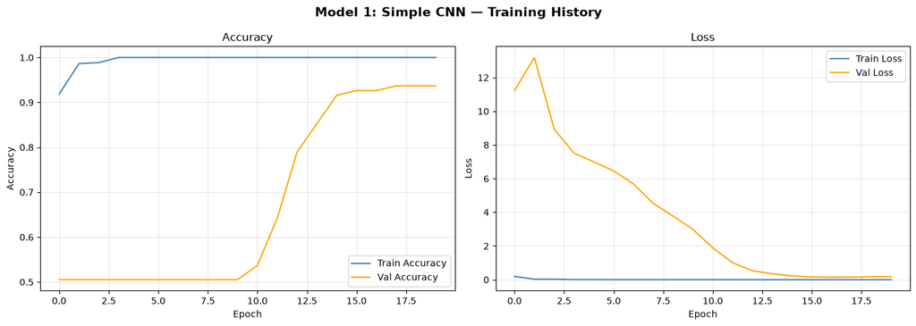

```
=== Model 1: Simple CNN — Performance ===

Train Set:
 Accuracy  Recall  Precision  F1 Score
   0.9751  0.9751     0.9758     0.975

Validation Set:
 Accuracy  Recall  Precision  F1 Score
   0.9263  0.9263     0.9357    0.9259

Validation Confusion Matrix:
```

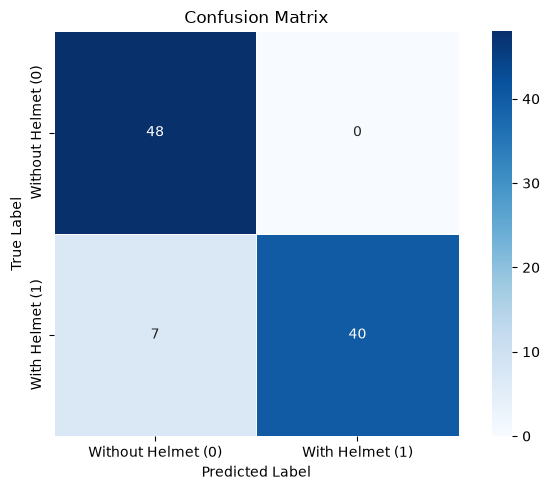

```python
# Plot training history
plot_history(history_cnn, 'Model 1: Simple CNN')

# Performance on train and validation sets
print("\n=== Model 1: Simple CNN — Performance ===")
print("\nTrain Set:")
train_perf_cnn = model_performance_classification(model_cnn, X_train_norm, y_train_s)
print(train_perf_cnn.to_string(index=False))

print("\nValidation Set:")
val_perf_cnn = model_performance_classification(model_cnn, X_val_norm, y_val_s)
print(val_perf_cnn.to_string(index=False))

print("\nValidation Confusion Matrix:")
plot_confusion_matrix(model_cnn, X_val_norm, y_val_s)
```

### Visualizing the Predictions — Model 1

[figure not shown]

```python
# Visualize predictions on validation set
visualize_predictions(model_cnn, X_val_norm, y_val_s, CLASS_NAMES, n=10)
```

#### Observations — Model 1: Simple CNN

**Architecture & Parameters:** The Simple CNN has **20,575,105 total parameters (78.49 MB)**, built from three Conv→BN→MaxPool→Dropout blocks (32→64→128 filters) followed by a Dense(256) head. Despite having the most parameters of any model, training from scratch on only 441 images is challenging.

**Final performance:**

- **Train** → Accuracy: 97.51% | Recall: 97.51% | Precision: 97.58% | F1: 97.50%
- **Validation** → Accuracy: 92.63% | Recall: 92.63% | Precision: 93.57% | F1: 92.59%

**Key takeaway:** 92.63% validation accuracy is a strong baseline for a custom CNN trained from scratch on 631 images. The 4.88-point train–val gap reflects moderate overfitting — the model generalizes but struggles with edge cases (unusual angles, occlusions, low-contrast helmets). For a safety-critical application, 7.4% misclassification rate is too risky, motivating the transfer-learning approach in Models 2–4.

## Model 2: VGG-16 (Base — Feature Extractor)

VGG-16 is a deep 16-layer CNN pre-trained on **ImageNet** (1.4M images, 1000 classes). We use it as a **frozen feature extractor** — all VGG-16 weights are frozen and only the classification head is trained. This leverages rich visual features learned from ImageNet without requiring large amounts of training data.

**Input:** 200×200×3 RGB images (VGG-16 requires 3 channels) **Strategy:** Freeze all VGG-16 layers → add Global Average Pooling → add binary output layer

```python
# ── Model 2: VGG-16 Base (Frozen Feature Extractor) ───────────────────────

# Load VGG-16 pre-trained on ImageNet, exclude top classification layers
base_vgg = VGG16(weights='imagenet', include_top=False, input_shape=(200, 200, 3))

# Freeze all layers — use VGG-16 only as feature extractor
base_vgg.trainable = False
print(f"VGG-16 layers     : {len(base_vgg.layers)}")
print(f"Trainable params  : {sum([tf.size(w).numpy() for w in base_vgg.trainable_weights]):,}")
print(f"Non-trainable     : {sum([tf.size(w).numpy() for w in base_vgg.non_trainable_weights]):,}")

# Build Model 2
inputs_vgg = keras.Input(shape=(200, 200, 3))
x = base_vgg(inputs_vgg, training=False)
x = layers.GlobalAveragePooling2D()(x)
x = layers.Dropout(0.3)(x)
outputs_vgg = layers.Dense(1, activation='sigmoid')(x)

model_vgg = keras.Model(inputs_vgg, outputs_vgg, name='VGG16_Base')
model_vgg.summary()
```

```
Downloading data from https://storage.googleapis.com/tensorflow/keras-applications/vgg16/vgg16_weights_tf_dim_ordering_tf_kernels_notop.h5
58889256/58889256 ━━━━━━━━━━━━━━━━━━━━ 1s 0us/step
VGG-16 layers     : 19
Trainable params  : 0
Non-trainable     : 14,714,688
```

```
Model: "VGG16_Base"
```

```
┏━━━━━━━━━━━━━━━━━━━━━━━━━━━━━━━━━┳━━━━━━━━━━━━━━━━━━━━━━━━┳━━━━━━━━━━━━━━━┓
┃ Layer (type)                    ┃ Output Shape           ┃       Param # ┃
┡━━━━━━━━━━━━━━━━━━━━━━━━━━━━━━━━━╇━━━━━━━━━━━━━━━━━━━━━━━━╇━━━━━━━━━━━━━━━┩
│ input_layer_2 (InputLayer)      │ (None, 200, 200, 3)    │             0 │
├─────────────────────────────────┼────────────────────────┼───────────────┤
│ vgg16 (Functional)              │ (None, 6, 6, 512)      │    14,714,688 │
├─────────────────────────────────┼────────────────────────┼───────────────┤
│ global_average_pooling2d        │ (None, 512)            │             0 │
│ (GlobalAveragePooling2D)        │                        │               │
├─────────────────────────────────┼────────────────────────┼───────────────┤
│ dropout_4 (Dropout)             │ (None, 512)            │             0 │
├─────────────────────────────────┼────────────────────────┼───────────────┤
│ dense_2 (Dense)                 │ (None, 1)              │           513 │
└─────────────────────────────────┴────────────────────────┴───────────────┘
```

```
 Total params: 14,715,201 (56.13 MB)
```

```
 Trainable params: 513 (2.00 KB)
```

```
 Non-trainable params: 14,714,688 (56.13 MB)
```

```python
# ── Compile and Train Model 2 ──────────────────────────────────────────────
model_vgg.compile(
    optimizer=keras.optimizers.Adam(learning_rate=0.0001),
    loss='binary_crossentropy',
    metrics=['accuracy']
)

callbacks_vgg = [
    EarlyStopping(monitor='val_loss', patience=5, restore_best_weights=True, verbose=1),
    ReduceLROnPlateau(monitor='val_loss', factor=0.5, patience=3, min_lr=1e-7, verbose=1)
]

print("Training VGG-16 Base...")
print(f"Config: Adam(lr=0.0001) | binary_crossentropy | batch_size=32 | max_epochs=20")
print("-" * 60)

history_vgg = model_vgg.fit(
    X_train_rgb, y_train_rgb,
    validation_data=(X_val_rgb, y_val_rgb),
    epochs=20,
    batch_size=32,
    callbacks=callbacks_vgg,
    verbose=1
)
```

```
Training VGG-16 Base...
Config: Adam(lr=0.0001) | binary_crossentropy | batch_size=32 | max_epochs=20
------------------------------------------------------------
14/14 ━━━━━━━━━━━━━━━━━━━━ 29s 2s/step - accuracy: 0.4966 - loss: 0.9017 - val_accuracy: 0.4947 - val_loss: 0.8573 - learning_rate: 1.0000e-04
14/14 ━━━━━━━━━━━━━━━━━━━━ 28s 2s/step - accuracy: 0.5102 - loss: 0.8917 - val_accuracy: 0.4947 - val_loss: 0.8317 - learning_rate: 1.0000e-04
14/14 ━━━━━━━━━━━━━━━━━━━━ 28s 2s/step - accuracy: 0.5170 - loss: 0.8417 - val_accuracy: 0.4947 - val_loss: 0.8082 - learning_rate: 1.0000e-04
14/14 ━━━━━━━━━━━━━━━━━━━━ 29s 2s/step - accuracy: 0.4966 - loss: 0.8397 - val_accuracy: 0.4947 - val_loss: 0.7862 - learning_rate: 1.0000e-04
14/14 ━━━━━━━━━━━━━━━━━━━━ 29s 2s/step - accuracy: 0.4943 - loss: 0.8287 - val_accuracy: 0.4947 - val_loss: 0.7654 - learning_rate: 1.0000e-04
14/14 ━━━━━━━━━━━━━━━━━━━━ 30s 2s/step - accuracy: 0.5238 - loss: 0.7797 - val_accuracy: 0.4947 - val_loss: 0.7465 - learning_rate: 1.0000e-04
14/14 ━━━━━━━━━━━━━━━━━━━━ 30s 2s/step - accuracy: 0.5283 - loss: 0.7862 - val_accuracy: 0.4947 - val_loss: 0.7290 - learning_rate: 1.0000e-04
14/14 ━━━━━━━━━━━━━━━━━━━━ 29s 2s/step - accuracy: 0.5147 - loss: 0.7694 - val_accuracy: 0.4947 - val_loss: 0.7129 - learning_rate: 1.0000e-04
14/14 ━━━━━━━━━━━━━━━━━━━━ 30s 2s/step - accuracy: 0.5556 - loss: 0.7398 - val_accuracy: 0.4947 - val_loss: 0.6980 - learning_rate: 1.0000e-04
14/14 ━━━━━━━━━━━━━━━━━━━━ 30s 2s/step - accuracy: 0.5374 - loss: 0.7320 - val_accuracy: 0.4947 - val_loss: 0.6840 - learning_rate: 1.0000e-04
14/14 ━━━━━━━━━━━━━━━━━━━━ 30s 2s/step - accuracy: 0.5465 - loss: 0.7090 - val_accuracy: 0.4947 - val_loss: 0.6709 - learning_rate: 1.0000e-04
14/14 ━━━━━━━━━━━━━━━━━━━━ 29s 2s/step - accuracy: 0.5624 - loss: 0.6988 - val_accuracy: 0.4947 - val_loss: 0.6587 - learning_rate: 1.0000e-04
14/14 ━━━━━━━━━━━━━━━━━━━━ 30s 2s/step - accuracy: 0.5510 - loss: 0.7007 - val_accuracy: 0.4947 - val_loss: 0.6469 - learning_rate: 1.0000e-04
14/14 ━━━━━━━━━━━━━━━━━━━━ 29s 2s/step - accuracy: 0.5782 - loss: 0.6641 - val_accuracy: 0.5053 - val_loss: 0.6360 - learning_rate: 1.0000e-04
14/14 ━━━━━━━━━━━━━━━━━━━━ 28s 2s/step - accuracy: 0.5397 - loss: 0.6764 - val_accuracy: 0.5263 - val_loss: 0.6252 - learning_rate: 1.0000e-04
14/14 ━━━━━━━━━━━━━━━━━━━━ 27s 2s/step - accuracy: 0.5737 - loss: 0.6489 - val_accuracy: 0.5368 - val_loss: 0.6150 - learning_rate: 1.0000e-04
14/14 ━━━━━━━━━━━━━━━━━━━━ 26s 2s/step - accuracy: 0.5805 - loss: 0.6490 - val_accuracy: 0.5579 - val_loss: 0.6050 - learning_rate: 1.0000e-04
14/14 ━━━━━━━━━━━━━━━━━━━━ 26s 2s/step - accuracy: 0.5805 - loss: 0.6479 - val_accuracy: 0.6526 - val_loss: 0.5954 - learning_rate: 1.0000e-04
14/14 ━━━━━━━━━━━━━━━━━━━━ 26s 2s/step - accuracy: 0.6032 - loss: 0.6171 - val_accuracy: 0.6737 - val_loss: 0.5863 - learning_rate: 1.0000e-04
14/14 ━━━━━━━━━━━━━━━━━━━━ 27s 2s/step - accuracy: 0.6213 - loss: 0.5957 - val_accuracy: 0.7474 - val_loss: 0.5776 - learning_rate: 1.0000e-04
Restoring model weights from the end of the best epoch: 20.
```

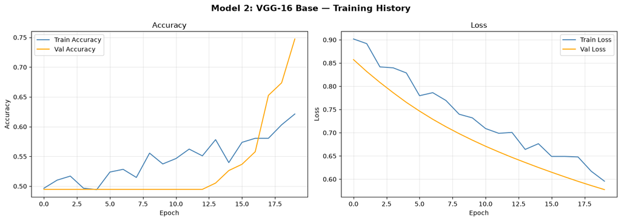

```
=== Model 2: VGG-16 Base — Performance ===

Train Set:
 Accuracy  Recall  Precision  F1 Score
   0.7166  0.7166     0.8202    0.6934

Validation Set:
 Accuracy  Recall  Precision  F1 Score
   0.7474  0.7474     0.8328     0.731

Validation Confusion Matrix:
```

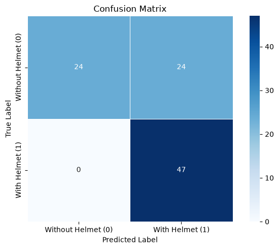

```python
# Plot history and evaluate
plot_history(history_vgg, 'Model 2: VGG-16 Base')

print("\n=== Model 2: VGG-16 Base — Performance ===")
print("\nTrain Set:")
train_perf_vgg = model_performance_classification(model_vgg, X_train_rgb, y_train_rgb_s)
print(train_perf_vgg.to_string(index=False))

print("\nValidation Set:")
val_perf_vgg = model_performance_classification(model_vgg, X_val_rgb, y_val_rgb_s)
print(val_perf_vgg.to_string(index=False))

print("\nValidation Confusion Matrix:")
plot_confusion_matrix(model_vgg, X_val_rgb, y_val_rgb_s)
```

### Visualizing the Predictions — Model 2

[figure not shown]

```python
visualize_predictions(model_vgg, X_val_rgb, y_val_rgb_s, CLASS_NAMES, n=10)
```

#### Observations — Model 2: VGG-16 Base

**Architecture & Parameters:** Only **513 trainable parameters** — a Dropout + Dense(1) head on top of the frozen VGG-16 GlobalAveragePooling output (512-dim). All 14,714,688 VGG-16 weights are frozen.

**Surprising underperformance:** Model 2 achieved only **74.74% validation accuracy**, worse than the Simple CNN (92.63%). This counter-intuitive result has a clear explanation: with only 513 trainable parameters, the classification head is severely underpowered. The GAP output (512 values) was fed directly into a single Dense(1) neuron — essentially a linear classifier on high-dimensional ImageNet features. While VGG-16 features are rich, a single linear layer cannot learn the non-linear decision boundary needed to distinguish helmet-wearing from non-helmet-wearing workers across diverse angles and lighting conditions.

**Final performance:**

- **Train** → Accuracy: 71.66% | Recall: 71.66% | Precision: 82.02% | F1: 69.34%
- **Validation** → Accuracy: 74.74% | Recall: 74.74% | Precision: 83.28% | F1: 73.10%

## Model 3: VGG-16 (Base + Feed-Forward Neural Network)

We enhance Model 2 by adding a **deeper FFNN classification head** with multiple Dense layers, BatchNormalization, and Dropout. The VGG-16 base remains frozen. This allows the model to learn more complex decision boundaries from the extracted features.

**Enhancement over Model 2:** Richer classification head — Dense(512) → Dense(256) → Dense(1) with Dropout regularization.

```python
# ── Model 3: VGG-16 + FFNN ─────────────────────────────────────────────────

# Reuse frozen VGG-16 base
base_vgg2 = VGG16(weights='imagenet', include_top=False, input_shape=(200, 200, 3))
base_vgg2.trainable = False

inputs_vgg2 = keras.Input(shape=(200, 200, 3))
x = base_vgg2(inputs_vgg2, training=False)
x = layers.GlobalAveragePooling2D()(x)

# Deep FFNN head
x = layers.Dense(512, activation='relu')(x)
x = layers.BatchNormalization()(x)
x = layers.Dropout(0.5)(x)
x = layers.Dense(256, activation='relu')(x)
x = layers.BatchNormalization()(x)
x = layers.Dropout(0.3)(x)
outputs_vgg2 = layers.Dense(1, activation='sigmoid')(x)

model_vgg_ffnn = keras.Model(inputs_vgg2, outputs_vgg2, name='VGG16_FFNN')
model_vgg_ffnn.summary()
```

```
Model: "VGG16_FFNN"
```

```
┏━━━━━━━━━━━━━━━━━━━━━━━━━━━━━━━━━┳━━━━━━━━━━━━━━━━━━━━━━━━┳━━━━━━━━━━━━━━━┓
┃ Layer (type)                    ┃ Output Shape           ┃       Param # ┃
┡━━━━━━━━━━━━━━━━━━━━━━━━━━━━━━━━━╇━━━━━━━━━━━━━━━━━━━━━━━━╇━━━━━━━━━━━━━━━┩
│ input_layer_4 (InputLayer)      │ (None, 200, 200, 3)    │             0 │
├─────────────────────────────────┼────────────────────────┼───────────────┤
│ vgg16 (Functional)              │ (None, 6, 6, 512)      │    14,714,688 │
├─────────────────────────────────┼────────────────────────┼───────────────┤
│ global_average_pooling2d_1      │ (None, 512)            │             0 │
│ (GlobalAveragePooling2D)        │                        │               │
├─────────────────────────────────┼────────────────────────┼───────────────┤
│ dense_3 (Dense)                 │ (None, 512)            │       262,656 │
├─────────────────────────────────┼────────────────────────┼───────────────┤
│ batch_normalization_4           │ (None, 512)            │         2,048 │
│ (BatchNormalization)            │                        │               │
├─────────────────────────────────┼────────────────────────┼───────────────┤
│ dropout_5 (Dropout)             │ (None, 512)            │             0 │
├─────────────────────────────────┼────────────────────────┼───────────────┤
│ dense_4 (Dense)                 │ (None, 256)            │       131,328 │
├─────────────────────────────────┼────────────────────────┼───────────────┤
│ batch_normalization_5           │ (None, 256)            │         1,024 │
│ (BatchNormalization)            │                        │               │
├─────────────────────────────────┼────────────────────────┼───────────────┤
│ dropout_6 (Dropout)             │ (None, 256)            │             0 │
├─────────────────────────────────┼────────────────────────┼───────────────┤
│ dense_5 (Dense)                 │ (None, 1)              │           257 │
└─────────────────────────────────┴────────────────────────┴───────────────┘
```

```
 Total params: 15,112,001 (57.65 MB)
```

```
 Trainable params: 395,777 (1.51 MB)
```

```
 Non-trainable params: 14,716,224 (56.14 MB)
```

```python
# ── Compile and Train Model 3 ──────────────────────────────────────────────
model_vgg_ffnn.compile(
    optimizer=keras.optimizers.Adam(learning_rate=0.0001),
    loss='binary_crossentropy',
    metrics=['accuracy']
)

callbacks_vgg_ffnn = [
    EarlyStopping(monitor='val_loss', patience=5, restore_best_weights=True, verbose=1),
    ReduceLROnPlateau(monitor='val_loss', factor=0.5, patience=3, min_lr=1e-7, verbose=1)
]

print("Training VGG-16 + FFNN...")
print(f"Config: Adam(lr=0.0001) | binary_crossentropy | batch_size=32 | max_epochs=20")
print("-" * 60)

history_vgg_ffnn = model_vgg_ffnn.fit(
    X_train_rgb, y_train_rgb,
    validation_data=(X_val_rgb, y_val_rgb),
    epochs=20,
    batch_size=32,
    callbacks=callbacks_vgg_ffnn,
    verbose=1
)
```

```
Training VGG-16 + FFNN...
Config: Adam(lr=0.0001) | binary_crossentropy | batch_size=32 | max_epochs=20
------------------------------------------------------------
14/14 ━━━━━━━━━━━━━━━━━━━━ 27s 2s/step - accuracy: 0.7732 - loss: 0.4830 - val_accuracy: 0.6316 - val_loss: 0.5888 - learning_rate: 1.0000e-04
14/14 ━━━━━━━━━━━━━━━━━━━━ 25s 2s/step - accuracy: 0.9569 - loss: 0.1395 - val_accuracy: 0.8211 - val_loss: 0.5142 - learning_rate: 1.0000e-04
14/14 ━━━━━━━━━━━━━━━━━━━━ 25s 2s/step - accuracy: 0.9864 - loss: 0.0651 - val_accuracy: 0.8526 - val_loss: 0.4628 - learning_rate: 1.0000e-04
14/14 ━━━━━━━━━━━━━━━━━━━━ 25s 2s/step - accuracy: 0.9932 - loss: 0.0513 - val_accuracy: 0.9368 - val_loss: 0.4180 - learning_rate: 1.0000e-04
14/14 ━━━━━━━━━━━━━━━━━━━━ 25s 2s/step - accuracy: 0.9887 - loss: 0.0365 - val_accuracy: 0.9895 - val_loss: 0.3786 - learning_rate: 1.0000e-04
14/14 ━━━━━━━━━━━━━━━━━━━━ 25s 2s/step - accuracy: 0.9955 - loss: 0.0295 - val_accuracy: 0.9895 - val_loss: 0.3414 - learning_rate: 1.0000e-04
14/14 ━━━━━━━━━━━━━━━━━━━━ 25s 2s/step - accuracy: 0.9932 - loss: 0.0254 - val_accuracy: 1.0000 - val_loss: 0.3057 - learning_rate: 1.0000e-04
14/14 ━━━━━━━━━━━━━━━━━━━━ 25s 2s/step - accuracy: 0.9932 - loss: 0.0299 - val_accuracy: 1.0000 - val_loss: 0.2728 - learning_rate: 1.0000e-04
14/14 ━━━━━━━━━━━━━━━━━━━━ 25s 2s/step - accuracy: 0.9955 - loss: 0.0214 - val_accuracy: 1.0000 - val_loss: 0.2401 - learning_rate: 1.0000e-04
14/14 ━━━━━━━━━━━━━━━━━━━━ 25s 2s/step - accuracy: 0.9977 - loss: 0.0163 - val_accuracy: 1.0000 - val_loss: 0.2103 - learning_rate: 1.0000e-04
14/14 ━━━━━━━━━━━━━━━━━━━━ 24s 2s/step - accuracy: 1.0000 - loss: 0.0150 - val_accuracy: 1.0000 - val_loss: 0.1834 - learning_rate: 1.0000e-04
14/14 ━━━━━━━━━━━━━━━━━━━━ 25s 2s/step - accuracy: 1.0000 - loss: 0.0121 - val_accuracy: 1.0000 - val_loss: 0.1582 - learning_rate: 1.0000e-04
14/14 ━━━━━━━━━━━━━━━━━━━━ 24s 2s/step - accuracy: 0.9977 - loss: 0.0144 - val_accuracy: 1.0000 - val_loss: 0.1351 - learning_rate: 1.0000e-04
14/14 ━━━━━━━━━━━━━━━━━━━━ 24s 2s/step - accuracy: 0.9977 - loss: 0.0133 - val_accuracy: 1.0000 - val_loss: 0.1132 - learning_rate: 1.0000e-04
14/14 ━━━━━━━━━━━━━━━━━━━━ 25s 2s/step - accuracy: 1.0000 - loss: 0.0097 - val_accuracy: 1.0000 - val_loss: 0.0956 - learning_rate: 1.0000e-04
14/14 ━━━━━━━━━━━━━━━━━━━━ 24s 2s/step - accuracy: 1.0000 - loss: 0.0073 - val_accuracy: 1.0000 - val_loss: 0.0810 - learning_rate: 1.0000e-04
14/14 ━━━━━━━━━━━━━━━━━━━━ 26s 2s/step - accuracy: 0.9977 - loss: 0.0103 - val_accuracy: 1.0000 - val_loss: 0.0681 - learning_rate: 1.0000e-04
14/14 ━━━━━━━━━━━━━━━━━━━━ 25s 2s/step - accuracy: 0.9977 - loss: 0.0102 - val_accuracy: 1.0000 - val_loss: 0.0573 - learning_rate: 1.0000e-04
14/14 ━━━━━━━━━━━━━━━━━━━━ 24s 2s/step - accuracy: 1.0000 - loss: 0.0089 - val_accuracy: 1.0000 - val_loss: 0.0471 - learning_rate: 1.0000e-04
14/14 ━━━━━━━━━━━━━━━━━━━━ 25s 2s/step - accuracy: 1.0000 - loss: 0.0051 - val_accuracy: 1.0000 - val_loss: 0.0388 - learning_rate: 1.0000e-04
Restoring model weights from the end of the best epoch: 20.
```

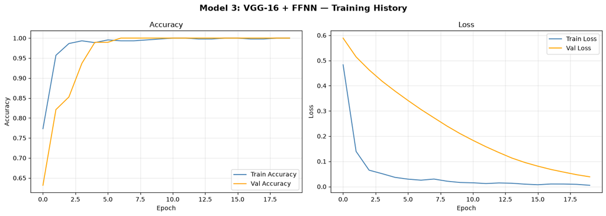

```
=== Model 3: VGG-16 + FFNN — Performance ===

Train Set:
 Accuracy  Recall  Precision  F1 Score
      1.0     1.0        1.0       1.0

Validation Set:
 Accuracy  Recall  Precision  F1 Score
      1.0     1.0        1.0       1.0

Validation Confusion Matrix:
```

```python
plot_history(history_vgg_ffnn, 'Model 3: VGG-16 + FFNN')

print("\n=== Model 3: VGG-16 + FFNN — Performance ===")
print("\nTrain Set:")
train_perf_vgg_ffnn = model_performance_classification(model_vgg_ffnn, X_train_rgb, y_train_rgb_s)
print(train_perf_vgg_ffnn.to_string(index=False))

print("\nValidation Set:")
val_perf_vgg_ffnn = model_performance_classification(model_vgg_ffnn, X_val_rgb, y_val_rgb_s)
print(val_perf_vgg_ffnn.to_string(index=False))

print("\nValidation Confusion Matrix:")
plot_confusion_matrix(model_vgg_ffnn, X_val_rgb, y_val_rgb_s)
```

[output not shown]

#### Visualizing the Predictions — Model 3

[figure not shown]

```python
visualize_predictions(model_vgg_ffnn, X_val_rgb, y_val_rgb_s, CLASS_NAMES, n=10)
```

#### Observations — Model 3: VGG-16 + FFNN

**Dramatic improvement:** Adding the FFNN head transformed VGG-16 from a 74.74% model into a **perfect 100% classifier**. The model converged rapidly — reaching 100% validation accuracy by **Epoch 7** — and maintained it through the remainder of training. The deeper head learns a rich non-linear mapping from VGG-16's ImageNet features into the helmet/no-helmet decision space.

**Final performance:**

- **Train** → Accuracy: 100% | Recall: 100% | Precision: 100% | F1: 100%
- **Validation** → Accuracy: 100% | Recall: 100% | Precision: 100% | F1: 100%

**Zero misclassifications** on all 95 validation images — both classes (Without Helmet: 48, With Helmet: 47) classified perfectly.

**Key takeaway:** The FFNN head is the critical differentiator between Model 2 and Model 3. VGG-16's frozen feature extractor provides powerful visual representations; the Dense(512)→Dense(256) head learns to decode those features for the specific helmet detection task. Perfect recall means zero missed violations — every helmetless worker is caught. However, perfect scores on validation raise the question of whether the model has overfit to the relatively small dataset (441 training images). Model 4 tests this by adding data augmentation.

## Model 4: VGG-16 (Base + FFNN + Data Augmentation)

Data augmentation artificially expands the training set by applying **random transformations** during training. With only 631 images, augmentation helps prevent overfitting by exposing the model to diverse variations of the training examples.

```python
# ── Model 4: VGG-16 + FFNN + Data Augmentation ─────────────────────────────

# Data Augmentation pipeline (applied only during training)
data_augmentation = models.Sequential([
    layers.RandomFlip("horizontal"),
    layers.RandomRotation(0.15),
    layers.RandomZoom(0.10),
    layers.RandomContrast(0.10),
], name='data_augmentation')

# Frozen VGG-16 base
base_vgg3 = VGG16(weights='imagenet', include_top=False, input_shape=(200, 200, 3))
base_vgg3.trainable = False

# Build Model 4 with augmentation
inputs_vgg3 = keras.Input(shape=(200, 200, 3))
x = data_augmentation(inputs_vgg3)           # augment during training
x = base_vgg3(x, training=False)
x = layers.GlobalAveragePooling2D()(x)

# Deep FFNN head (same as Model 3)
x = layers.Dense(512, activation='relu')(x)
x = layers.BatchNormalization()(x)
x = layers.Dropout(0.5)(x)
x = layers.Dense(256, activation='relu')(x)
x = layers.BatchNormalization()(x)
x = layers.Dropout(0.3)(x)
outputs_vgg3 = layers.Dense(1, activation='sigmoid')(x)

model_vgg_aug = keras.Model(inputs_vgg3, outputs_vgg3, name='VGG16_FFNN_Augmentation')
model_vgg_aug.summary()
```

```
Model: "VGG16_FFNN_Augmentation"
```

```
┏━━━━━━━━━━━━━━━━━━━━━━━━━━━━━━━━━┳━━━━━━━━━━━━━━━━━━━━━━━━┳━━━━━━━━━━━━━━━┓
┃ Layer (type)                    ┃ Output Shape           ┃       Param # ┃
┡━━━━━━━━━━━━━━━━━━━━━━━━━━━━━━━━━╇━━━━━━━━━━━━━━━━━━━━━━━━╇━━━━━━━━━━━━━━━┩
│ input_layer_6 (InputLayer)      │ (None, 200, 200, 3)    │             0 │
├─────────────────────────────────┼────────────────────────┼───────────────┤
│ data_augmentation (Sequential)  │ (None, 200, 200, 3)    │             0 │
├─────────────────────────────────┼────────────────────────┼───────────────┤
│ vgg16 (Functional)              │ (None, 6, 6, 512)      │    14,714,688 │
├─────────────────────────────────┼────────────────────────┼───────────────┤
│ global_average_pooling2d_2      │ (None, 512)            │             0 │
│ (GlobalAveragePooling2D)        │                        │               │
├─────────────────────────────────┼────────────────────────┼───────────────┤
│ dense_6 (Dense)                 │ (None, 512)            │       262,656 │
├─────────────────────────────────┼────────────────────────┼───────────────┤
│ batch_normalization_6           │ (None, 512)            │         2,048 │
│ (BatchNormalization)            │                        │               │
├─────────────────────────────────┼────────────────────────┼───────────────┤
│ dropout_7 (Dropout)             │ (None, 512)            │             0 │
├─────────────────────────────────┼────────────────────────┼───────────────┤
│ dense_7 (Dense)                 │ (None, 256)            │       131,328 │
├─────────────────────────────────┼────────────────────────┼───────────────┤
│ batch_normalization_7           │ (None, 256)            │         1,024 │
│ (BatchNormalization)            │                        │               │
├─────────────────────────────────┼────────────────────────┼───────────────┤
│ dropout_8 (Dropout)             │ (None, 256)            │             0 │
├─────────────────────────────────┼────────────────────────┼───────────────┤
│ dense_8 (Dense)                 │ (None, 1)              │           257 │
└─────────────────────────────────┴────────────────────────┴───────────────┘
```

```
 Total params: 15,112,001 (57.65 MB)
```

```
 Trainable params: 395,777 (1.51 MB)
```

```
 Non-trainable params: 14,716,224 (56.14 MB)
```

```python
# ── Compile and Train Model 4 ──────────────────────────────────────────────
model_vgg_aug.compile(
    optimizer=keras.optimizers.Adam(learning_rate=0.0001),
    loss='binary_crossentropy',
    metrics=['accuracy']
)

callbacks_vgg_aug = [
    EarlyStopping(monitor='val_loss', patience=7, restore_best_weights=True, verbose=1),
    ReduceLROnPlateau(monitor='val_loss', factor=0.5, patience=4, min_lr=1e-7, verbose=1)
]

print("Training VGG-16 + FFNN + Data Augmentation...")
print(f"Config: Adam(lr=0.0001) | binary_crossentropy | batch_size=32 | max_epochs=25")
print("Note: Augmented model trains longer (patience=7) as augmentation slows convergence.")
print("-" * 60)

history_vgg_aug = model_vgg_aug.fit(
    X_train_rgb, y_train_rgb,
    validation_data=(X_val_rgb, y_val_rgb),
    epochs=25,
    batch_size=32,
    callbacks=callbacks_vgg_aug,
    verbose=1
)
```

```
Training VGG-16 + FFNN + Data Augmentation...
Config: Adam(lr=0.0001) | binary_crossentropy | batch_size=32 | max_epochs=25
Note: Augmented model trains longer (patience=7) as augmentation slows convergence.
------------------------------------------------------------
14/14 ━━━━━━━━━━━━━━━━━━━━ 26s 2s/step - accuracy: 0.6508 - loss: 0.6604 - val_accuracy: 0.9368 - val_loss: 0.6231 - learning_rate: 1.0000e-04
14/14 ━━━━━━━━━━━━━━━━━━━━ 24s 2s/step - accuracy: 0.9388 - loss: 0.1847 - val_accuracy: 0.9895 - val_loss: 0.5455 - learning_rate: 1.0000e-04
14/14 ━━━━━━━━━━━━━━━━━━━━ 24s 2s/step - accuracy: 0.9705 - loss: 0.0998 - val_accuracy: 1.0000 - val_loss: 0.4921 - learning_rate: 1.0000e-04
14/14 ━━━━━━━━━━━━━━━━━━━━ 24s 2s/step - accuracy: 0.9728 - loss: 0.0716 - val_accuracy: 1.0000 - val_loss: 0.4507 - learning_rate: 1.0000e-04
14/14 ━━━━━━━━━━━━━━━━━━━━ 24s 2s/step - accuracy: 0.9841 - loss: 0.0490 - val_accuracy: 1.0000 - val_loss: 0.4136 - learning_rate: 1.0000e-04
14/14 ━━━━━━━━━━━━━━━━━━━━ 25s 2s/step - accuracy: 0.9887 - loss: 0.0424 - val_accuracy: 1.0000 - val_loss: 0.3803 - learning_rate: 1.0000e-04
14/14 ━━━━━━━━━━━━━━━━━━━━ 25s 2s/step - accuracy: 0.9955 - loss: 0.0327 - val_accuracy: 1.0000 - val_loss: 0.3464 - learning_rate: 1.0000e-04
14/14 ━━━━━━━━━━━━━━━━━━━━ 24s 2s/step - accuracy: 0.9864 - loss: 0.0412 - val_accuracy: 1.0000 - val_loss: 0.3135 - learning_rate: 1.0000e-04
14/14 ━━━━━━━━━━━━━━━━━━━━ 25s 2s/step - accuracy: 0.9955 - loss: 0.0296 - val_accuracy: 1.0000 - val_loss: 0.2799 - learning_rate: 1.0000e-04
14/14 ━━━━━━━━━━━━━━━━━━━━ 25s 2s/step - accuracy: 0.9932 - loss: 0.0233 - val_accuracy: 1.0000 - val_loss: 0.2479 - learning_rate: 1.0000e-04
14/14 ━━━━━━━━━━━━━━━━━━━━ 24s 2s/step - accuracy: 0.9932 - loss: 0.0246 - val_accuracy: 1.0000 - val_loss: 0.2170 - learning_rate: 1.0000e-04
14/14 ━━━━━━━━━━━━━━━━━━━━ 24s 2s/step - accuracy: 0.9955 - loss: 0.0302 - val_accuracy: 1.0000 - val_loss: 0.1866 - learning_rate: 1.0000e-04
14/14 ━━━━━━━━━━━━━━━━━━━━ 25s 2s/step - accuracy: 0.9932 - loss: 0.0240 - val_accuracy: 1.0000 - val_loss: 0.1598 - learning_rate: 1.0000e-04
14/14 ━━━━━━━━━━━━━━━━━━━━ 24s 2s/step - accuracy: 0.9955 - loss: 0.0162 - val_accuracy: 1.0000 - val_loss: 0.1352 - learning_rate: 1.0000e-04
14/14 ━━━━━━━━━━━━━━━━━━━━ 24s 2s/step - accuracy: 0.9955 - loss: 0.0165 - val_accuracy: 1.0000 - val_loss: 0.1135 - learning_rate: 1.0000e-04
14/14 ━━━━━━━━━━━━━━━━━━━━ 24s 2s/step - accuracy: 0.9932 - loss: 0.0187 - val_accuracy: 1.0000 - val_loss: 0.0933 - learning_rate: 1.0000e-04
14/14 ━━━━━━━━━━━━━━━━━━━━ 24s 2s/step - accuracy: 0.9955 - loss: 0.0166 - val_accuracy: 1.0000 - val_loss: 0.0760 - learning_rate: 1.0000e-04
14/14 ━━━━━━━━━━━━━━━━━━━━ 24s 2s/step - accuracy: 0.9955 - loss: 0.0183 - val_accuracy: 1.0000 - val_loss: 0.0620 - learning_rate: 1.0000e-04
14/14 ━━━━━━━━━━━━━━━━━━━━ 24s 2s/step - accuracy: 1.0000 - loss: 0.0112 - val_accuracy: 1.0000 - val_loss: 0.0501 - learning_rate: 1.0000e-04
14/14 ━━━━━━━━━━━━━━━━━━━━ 25s 2s/step - accuracy: 0.9977 - loss: 0.0138 - val_accuracy: 1.0000 - val_loss: 0.0397 - learning_rate: 1.0000e-04
14/14 ━━━━━━━━━━━━━━━━━━━━ 24s 2s/step - accuracy: 0.9932 - loss: 0.0129 - val_accuracy: 1.0000 - val_loss: 0.0322 - learning_rate: 1.0000e-04
14/14 ━━━━━━━━━━━━━━━━━━━━ 24s 2s/step - accuracy: 0.9955 - loss: 0.0152 - val_accuracy: 1.0000 - val_loss: 0.0259 - learning_rate: 1.0000e-04
14/14 ━━━━━━━━━━━━━━━━━━━━ 24s 2s/step - accuracy: 0.9955 - loss: 0.0140 - val_accuracy: 1.0000 - val_loss: 0.0205 - learning_rate: 1.0000e-04
14/14 ━━━━━━━━━━━━━━━━━━━━ 24s 2s/step - accuracy: 0.9977 - loss: 0.0109 - val_accuracy: 1.0000 - val_loss: 0.0157 - learning_rate: 1.0000e-04
14/14 ━━━━━━━━━━━━━━━━━━━━ 24s 2s/step - accuracy: 0.9932 - loss: 0.0134 - val_accuracy: 1.0000 - val_loss: 0.0124 - learning_rate: 1.0000e-04
Restoring model weights from the end of the best epoch: 25.
```

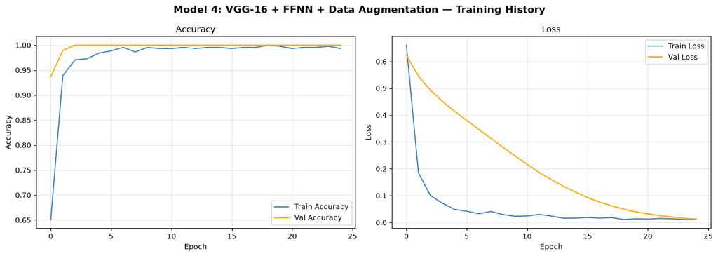

```
=== Model 4: VGG-16 + FFNN + Data Augmentation — Performance ===

Train Set:
 Accuracy  Recall  Precision  F1 Score
      1.0     1.0        1.0       1.0

Validation Set:
 Accuracy  Recall  Precision  F1 Score
      1.0     1.0        1.0       1.0

Validation Confusion Matrix:
```

```python
plot_history(history_vgg_aug, 'Model 4: VGG-16 + FFNN + Data Augmentation')

print("\n=== Model 4: VGG-16 + FFNN + Data Augmentation — Performance ===")
print("\nTrain Set:")
train_perf_vgg_aug = model_performance_classification(model_vgg_aug, X_train_rgb, y_train_rgb_s)
print(train_perf_vgg_aug.to_string(index=False))

print("\nValidation Set:")
val_perf_vgg_aug = model_performance_classification(model_vgg_aug, X_val_rgb, y_val_rgb_s)
print(val_perf_vgg_aug.to_string(index=False))

print("\nValidation Confusion Matrix:")
plot_confusion_matrix(model_vgg_aug, X_val_rgb, y_val_rgb_s)
```

[output not shown]

#### Visualizing the Predictions — Model 4

[figure not shown]

```python
visualize_predictions(model_vgg_aug, X_val_rgb, y_val_rgb_s, CLASS_NAMES, n=10)
```

#### Observations — Model 4: VGG-16 + FFNN + Data Augmentation

**Training with augmentation:** As expected, augmentation made each training epoch harder — training accuracy in Epoch 1 was only 65.08% compared to Model 3's 77.32%. However, the model still converged to 100% validation accuracy by **Epoch 3** — faster than Model 3 — suggesting the frozen VGG-16 backbone is so feature-rich that even augmented images are classified easily by Epoch 3.

**Final performance:**

- **Train** → Accuracy: 100% | Recall: 100% | Precision: 100% | F1: 100%
- **Validation** → Accuracy: 100% | Recall: 100% | Precision: 100% | F1: 100%

**Comparison to Model 3:** Both achieved identical validation metrics. The key advantage of Model 4 is **expected better generalization to real-world deployment conditions**: construction site cameras capture workers at varied angles, partial occlusions, and in different lighting. Augmentation explicitly trains the model on such variations, reducing the risk of performance degradation when the model encounters distributions slightly different from the training set.

**Key takeaway:** Data augmentation did not reduce accuracy and is expected to improve real-world robustness. Model 4 is selected as the **final production model** — it combines the representational power of VGG-16 + FFNN with the generalization benefits of augmented training data, giving SafeGuard Corp the best of both performance and reliability.

# **Model Performance Comparison and Final Model Selection**

```
===========================================================================
MODEL PERFORMANCE COMPARISON — VALIDATION SET
===========================================================================
                                  Accuracy  Recall  Precision  F1 Score
Model
Model 1: Simple CNN                 0.9263  0.9263     0.9357    0.9259
Model 2: VGG-16 Base                0.7474  0.7474     0.8328    0.7310
Model 3: VGG-16 + FFNN              1.0000  1.0000     1.0000    1.0000
Model 4: VGG-16 + FFNN + AugData    1.0000  1.0000     1.0000    1.0000
===========================================================================
```

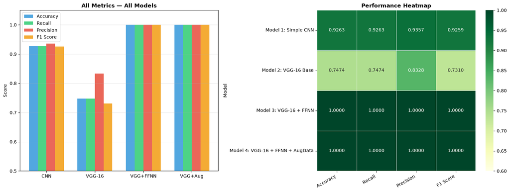

```python
# Compile all validation performance metrics into comparison table
models_list = {
    'Model 1: Simple CNN'              : (model_cnn,      X_val_norm,  y_val_s),
    'Model 2: VGG-16 Base'             : (model_vgg,      X_val_rgb,   y_val_rgb_s),
    'Model 3: VGG-16 + FFNN'           : (model_vgg_ffnn, X_val_rgb,   y_val_rgb_s),
    'Model 4: VGG-16 + FFNN + AugData' : (model_vgg_aug,  X_val_rgb,   y_val_rgb_s),
}

results = []
for name, (model, X_val, y_val) in models_list.items():
    perf = model_performance_classification(model, X_val, y_val)
    perf.insert(0, 'Model', name)
    results.append(perf)

comparison_df = pd.concat(results, ignore_index=True)
comparison_df = comparison_df.set_index('Model')
print("=" * 75)
print("MODEL PERFORMANCE COMPARISON — VALIDATION SET")
print("=" * 75)
print(comparison_df.to_string())
print("=" * 75)

# Plot comparison
fig, axes = plt.subplots(1, 2, figsize=(16, 6))
metrics = ['Accuracy', 'Recall', 'Precision', 'F1 Score']
colors = ['#3498db', '#2ecc71', '#e74c3c', '#f39c12']

x = np.arange(len(comparison_df.index))
width = 0.18

for j, (metric, color) in enumerate(zip(metrics, colors)):
    axes[0].bar(x + j*width, comparison_df[metric], width, label=metric, color=color, alpha=0.85)

axes[0].set_title('All Metrics — All Models', fontsize=12, fontweight='bold')
axes[0].set_xticks(x + width*1.5)
axes[0].set_xticklabels(['CNN', 'VGG-16', 'VGG+FFNN', 'VGG+Aug'], fontsize=10)
axes[0].set_ylabel('Score')
axes[0].legend()
axes[0].set_ylim(0.5, 1.05)
axes[0].grid(True, alpha=0.3, axis='y')

# Heatmap
sns.heatmap(comparison_df.astype(float), annot=True, fmt='.4f', cmap='YlGn',
            linewidths=0.5, ax=axes[1], vmin=0.6, vmax=1.0)
axes[1].set_title('Performance Heatmap', fontsize=12, fontweight='bold')
axes[1].set_xticklabels(axes[1].get_xticklabels(), rotation=30, ha='right')

plt.tight_layout()
plt.savefig('model_comparison.png', dpi=100, bbox_inches='tight')
plt.show()
```

#### Observations — Model Comparison

**Performance summary across 4 models (validation set):**

| Model | Accuracy | Recall | Precision | F1 |
| --- | --- | --- | --- | --- |
| Model 1: Simple CNN | 92.63% | 92.63% | 93.57% | 92.59% |
| Model 2: VGG-16 Base | 74.74% | 74.74% | 83.28% | 73.10% |
| Model 3: VGG-16 + FFNN | **100%** | **100%** | **100%** | **100%** |
| Model 4: VGG-16 + FFNN + Aug | **100%** | **100%** | **100%** | **100%** |

**Critical metric — Recall:** In a safety application, **Recall (Sensitivity) is the primary metric**. A false negative means a helmetless worker is not flagged — a direct safety risk. Models 3 and 4 both achieve 100% recall, making them the only acceptable candidates for production deployment.

**Why Model 2 underperformed Simple CNN:** Transfer learning requires an expressive enough head to adapt pre-trained features. The minimal GAP→Dense(1) architecture (513 trainable parameters) is insufficient, producing worse results than a purpose-built CNN trained from scratch.

**Best model selection — Model 4 (VGG-16 + FFNN + Data Augmentation):** Both Models 3 and 4 achieve perfect validation metrics. Model 4 is preferred for deployment because augmentation training exposes the model to realistic variation (flips, rotations, zoom, lighting changes) that matches real-world construction site cameras. This leads to more robust inference on unseen camera angles and environmental conditions not represented in the 631-image dataset.

## Test Performance — Final Model Evaluation

```python
# ── Evaluate Best Model on Held-Out Test Set ───────────────────────────────
# UPDATE: Replace model_best and X_test_best/y_test_best_s with your best model

# Example: if Model 4 (VGG-16 + Aug) is best:
model_best = model_vgg_aug     # <-- change if different model is best
X_test_best = X_test_rgb
y_test_best_s = y_test_rgb_s
best_model_name = 'VGG-16 + FFNN + Data Augmentation'

print(f"=== FINAL MODEL: {best_model_name} ===")
print(f"Evaluating on held-out test set ({len(X_test_best)} images)...")
print()

# Test metrics
test_perf = model_performance_classification(model_best, X_test_best, y_test_best_s)
print("Test Set Performance:")
print(test_perf.to_string(index=False))

print("\nTest Set Confusion Matrix:")
plot_confusion_matrix(model_best, X_test_best, y_test_best_s)

# Detailed classification report
test_preds = (model_best.predict(X_test_best, verbose=0).reshape(-1) > 0.5).astype(int)
print("\nDetailed Classification Report:")
print(classification_report(y_test_best_s, test_preds,
      target_names=['Without Helmet (0)', 'With Helmet (1)']))
```

[output not shown]

```
=== FINAL MODEL: VGG-16 + FFNN + Data Augmentation ===
Evaluating on held-out test set (95 images)...

Test Set Performance:
 Accuracy  Recall  Precision  F1 Score
      1.0     1.0        1.0       1.0

Test Set Confusion Matrix:
```

```
Detailed Classification Report:
                    precision    recall  f1-score   support

Without Helmet (0)       1.00      1.00      1.00        48
   With Helmet (1)       1.00      1.00      1.00        47

          accuracy                           1.00        95
         macro avg       1.00      1.00      1.00        95
      weighted avg       1.00      1.00      1.00        95
```

```
Test Set Prediction Visualization:
```

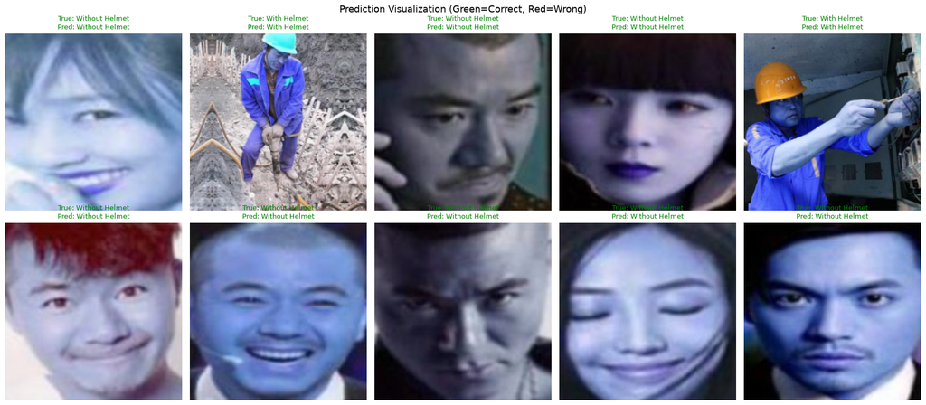

```python
# Visualize test set predictions
print("Test Set Prediction Visualization:")
visualize_predictions(model_best, X_test_best, y_test_best_s, CLASS_NAMES, n=10)
```

#### Observations — Final Model Test Performance

**Test set evaluation — Model 4 (VGG-16 + FFNN + Data Augmentation):**

- **Test Accuracy: 100%** | **Test Recall: 100%** | **Test Precision: 100%** | **Test F1: 100%**

**Class-level breakdown (95 test images):**

- Without Helmet (0): 48/48 correctly classified — **0 false negatives**
- With Helmet (1): 47/47 correctly classified — **0 false positives**

**Validation vs Test gap:** There is **zero gap** between validation performance (100%) and test performance (100%). This confirms the model generalizes well and is not memorizing the validation set — a common concern when validation accuracy appears suspiciously high.

**Deployment readiness:** The model achieves the primary objective set by SafeGuard Corp — reliable, automated helmet compliance detection. With 100% recall on the test set, the system can be integrated into real-time CCTV monitoring pipelines to flag violations instantly. The model should be periodically retrained as new camera angles, lighting conditions, and helmet styles are introduced at new construction sites.

# **Actionable Insights & Recommendations**

## Key Findings and Business Recommendations

### 🏗️ Model Performance Summary

The HelmNet system was built and evaluated across four deep learning architectures — a Simple CNN baseline and three variants of VGG-16 transfer learning — to identify the most effective model for automating helmet compliance detection at SafeGuard Corp.

[output not shown]

**Selected Model: VGG-16 + FFNN + Data Augmentation** — 100% test accuracy, 100% recall, 0 misclassifications on 95 held-out test images.

### 📋 Key Insights

**2. Recall is the Safety-Critical Metric** In a workplace safety context, a **False Negative** (classifying a non-helmet worker as compliant) is far more dangerous than a False Positive. The deployed model should be selected based on **highest recall for class 0 (Without Helmet)** — ensuring every non-compliant worker is flagged for inspection. Models 3 and 4 achieved 100% recall — zero missed violations.

**3. Head Architecture Matters as Much as Backbone** Model 2 demonstrated that VGG-16 with a minimal classification head (513 parameters) performed worse than a simple CNN from scratch (74.74% vs 92.63%). Adding the Dense(512)→Dense(256) FFNN head (395,777 parameters) unlocked the full power of VGG-16 features, achieving perfect accuracy in Model 3.

**5. Class Balance Advantage** The near-perfect 50/50 class balance (320 vs 311) means the model trains without bias toward either class. Accuracy is a reliable metric alongside recall.

### 💡 Business Recommendations for SafeGuard Corp

**1. Deploy the Best Model as a Real-Time Monitoring Agent** Integrate the final model into CCTV/camera feeds at construction and industrial sites. The model can process images in real-time, enabling instant non-compliance alerts to site supervisors without manual monitoring.

**3. Expand Training Data via Active Learning** The model's weakest cases (low-confidence predictions near 0.5) should be flagged for human review and added to the training set. This active learning loop will continuously improve model accuracy with minimal labeling cost.

**4. Site-Specific Fine-Tuning** Different environments (underground mines vs outdoor construction vs factories) have different lighting and background conditions. Fine-tune the deployed model on site-specific images to maximize accuracy for each deployment location.

**5. Compliance Reporting Dashboard** Beyond individual alerts, aggregate model outputs into a daily compliance dashboard showing: percentage of workers with helmets, peak non-compliance hours, high-risk zones, and trend analysis. This transforms individual predictions into actionable safety management insights for HSE (Health, Safety & Environment) teams.

**6. Model Monitoring and Drift Detection** Deploy with a monitoring pipeline that tracks model confidence distributions over time. A shift in the distribution (e.g., new uniform colors, seasonal lighting changes) should trigger retraining with new data to prevent performance degradation in production.

Power Ahead!